**Natalia Castilla Reyes**

**Miguel Angel Quintero**

```python
from google.colab import drive
drive.mount('/content/drive')
```

# 📑 Pronóstico de las ventas de diversos productos y evaluación de la satisfacción de los clientes de Walmart (US) mediante redes neuronales.

```python
import os
os.environ["JAVA_HOME"] = "/usr/lib/jvm/java-8-openjdk-amd64"
os.environ["SPARK_HOME"] = "/content/spark-2.4.8-bin-hadoop2.7"
#######################SPARK
!apt-get install openjdk-8-jdk-headless -qq > /dev/null
!wget -q https://downloads.apache.org/spark/spark-2.4.8/spark-2.4.8-bin-hadoop2.7.tgz
!tar xf spark-2.4.8-bin-hadoop2.7.tgz
```

```python
#@title Librerias necesarias
#Librerias generales

import time
import math
import datetime

import numpy as np
import pandas as pd
from tqdm.notebook import tqdm as tqdm
import pickle
import seaborn as sns
from matplotlib import colors
import matplotlib.pyplot as plt
from matplotlib.colors import Normalize
import plotly
import plotly.express as px
import plotly.graph_objects as go
import plotly.figure_factory as ff
from plotly.subplots import make_subplots
import dask
import joblib
from dask.dataframe import DataFrame as dd
import warnings

#Configuraciones
warnings.filterwarnings("ignore")
pd.set_option('max_columns', 50)
plt.style.use('bmh')
color_pal = plt.rcParams['axes.prop_cycle'].by_key()['color']
pd.options.display.max_columns = 400

#########Modelos

import xgboost as xgb
import lightgbm as lgb
from lightgbm import LGBMRegressor




from sklearn.metrics import mean_squared_error
from sklearn.preprocessing import MinMaxScaler
scaler = MinMaxScaler(feature_range=(0, 1))

#Tensor Flow
from __future__ import absolute_import, division, print_function, unicode_literals

import tensorflow as tf

# importa objetos de keras
from tensorflow.keras.models import Model
from tensorflow.keras.layers import Input, Dense, Dropout, LSTM
print("Versión de Tensorflow: ", tf.__version__)
# optimizador
from tensorflow.keras.optimizers import Adam
from tensorflow.keras import layers
from tensorflow.keras import regularizers
from tensorflow.keras import callbacks
from tensorflow.keras.callbacks import EarlyStopping


##Para definir la funcion de perdida que necesitaos en keeras

from keras import backend as K

#Variable global

DAYS_PRED = 28
ruta = "/content/drive/MyDrive/Proyecto_topicos/"
```

```
Versión de Tensorflow:  2.5.0
```

## 4. 🧮 Ingeniería de variables

Como probaremos varios modelos, entre ellos modelos de machine learning (LGBM), debemos vectorizar las variables para que el modelo entienda la temporalidad de los datos. Algunas de estas variables son por ejemplo: variables tendenciales, de retraso, promedios por mes, por día entre otras.

Temas de esta sección:

## 4.1 Label Encoding

```python
##Transformando algunas variables a tipo categórico.
df['id'] = df['id'].astype("category")
df['item_id'] = df['item_id'].astype("category")
df['dept_id'] = df['dept_id'].astype("category")
df['cat_id'] = df['cat_id'].astype("category")
df['store_id'] = df['store_id'].astype("category")
df['state_id'] = df['state_id'].astype("category")

#Guardando  las categorías
d_id = dict(zip(df.id.cat.codes, df.id))
d_item_id = dict(zip(df.item_id.cat.codes, df.item_id))
d_dept_id = dict(zip(df.dept_id.cat.codes, df.dept_id))
d_cat_id = dict(zip(df.cat_id.cat.codes, df.cat_id))
d_store_id = dict(zip(df.store_id.cat.codes, df.store_id))
d_state_id = dict(zip(df.state_id.cat.codes, df.state_id))
```

```python
#del group, group_price_cat, group_price_store, group_state, group_state_store, cal_data ##Liberando memoria


#2
df.d = df['d'].apply(lambda x: x.split('_')[1]).astype(float) #Estamos extrayendo el día únicamente de la variable d
cols = df.dtypes.index.tolist()
types = df.dtypes.values.tolist()
for i,type in enumerate(types):
    if type.name == 'category':
        df[cols[i]] = df[cols[i]].cat.codes

#3
#df.drop('date',axis=1,inplace=True)
```

## 4.2 Creación de variables de retraso

Volver a los temas de esta sección

Incluir variables de retraso es una de las maneras de realizar modelos de series de tiempo empleando algoritmos de machine learning. La variable que deseamos predecir es 'sold' (Cantidad de productos vendidos).

Aquí introducimos hasta el lag 46.

```python
#Introduce lags
lags = [1,2,6,12,24,36,46]
for lag in lags:
    df['sold_lag_'+str(lag)] = df.groupby(['id', 'item_id', 'dept_id', 'cat_id', 'store_id', 'state_id'],as_index=False)['sold'].shift(lag)
```

```python
df.head()
```

|  | store_id | item_id | wm_yr_wk | d | id | dept_id | cat_id | state_id | sold | date | weekday | wday | month | year | event_name_1 | event_type_1 | event_name_2 | event_type_2 | snap_CA | snap_TX | snap_WI | sell_price | revenue | sold_lag_1 | sold_lag_2 | sold_lag_6 | sold_lag_12 | sold_lag_24 | sold_lag_36 | … |
| --- | --- | --- | --- | --- | --- | --- | --- | --- | --- | --- | --- | --- | --- | --- | --- | --- | --- | --- | --- | --- | --- | --- | --- | --- | --- | --- | --- | --- | --- | --- |
| 133 | 0 | 0 | 7 | 1114.0 | 0 | 0 | 0 | 0 | 0.0 | 2014-02-15 | 2 | 1 | 2 | 2014.0 | -1 | -1 | -1 | -1 | 0 | 1 | 1 | 2.240234 | 0.000000 | NaN | NaN | NaN | NaN | NaN | NaN | … |
| 134 | 0 | 0 | 7 | 1115.0 | 0 | 0 | 0 | 0 | 2.0 | 2014-02-16 | 3 | 2 | 2 | 2014.0 | -1 | -1 | -1 | -1 | 0 | 0 | 0 | 2.240234 | 4.480469 | 0.0 | NaN | NaN | NaN | NaN | NaN | … |
| 135 | 0 | 0 | 7 | 1116.0 | 0 | 0 | 0 | 0 | 1.0 | 2014-02-17 | 1 | 3 | 2 | 2014.0 | 22 | 1 | -1 | -1 | 0 | 0 | 0 | 2.240234 | 2.240234 | 2.0 | 0.0 | NaN | NaN | NaN | NaN | … |
| 136 | 0 | 0 | 7 | 1117.0 | 0 | 0 | 0 | 0 | 0.0 | 2014-02-18 | 5 | 4 | 2 | 2014.0 | -1 | -1 | -1 | -1 | 0 | 0 | 0 | 2.240234 | 0.000000 | 1.0 | 2.0 | NaN | NaN | NaN | NaN | … |
| 137 | 0 | 0 | 7 | 1118.0 | 0 | 0 | 0 | 0 | 0.0 | 2014-02-19 | 6 | 5 | 2 | 2014.0 | -1 | -1 | -1 | -1 | 0 | 0 | 0 | 2.240234 | 0.000000 | 0.0 | 1.0 | NaN | NaN | NaN | NaN | … |

## 4.3 Introduciendo variables que tienen información del valor promedio de diferentes cantidades

Volver a los temas de esta sección

Para introducir este tipo de variables debemos tener mucho cuidado de no incluir información del conjunto de prueba en el conjunto de entrenamiento.

**Nuestro conjunto de entrenamiento consta de los días entre 1 hasta 1914**

**Nuestro conjunto de prueba está entre los días 1914 y 1942**

```python
df['iteam_sold_avg'] = df.groupby(['item_id', 'weekday', 'year'])['sold'].transform('mean')
df['state_sold_avg'] = df.groupby(['state_id', 'weekday', 'year'])['sold'].transform('mean')
df['store_sold_avg'] = df.groupby(['store_id', 'weekday', 'year'])['sold'].transform('mean')
df['cat_sold_avg'] = df.groupby(['cat_id','weekday', 'year'])['sold'].transform('mean')
df['dept_sold_avg'] = df.groupby(['dept_id','weekday', 'year'])['sold'].transform('mean')
df['cat_dept_sold_avg'] = df.groupby(['cat_id','dept_id', 'weekday', 'year'])['sold'].transform('mean')
df['store_item_sold_avg'] = df.groupby(['store_id','item_id','weekday', 'year'])['sold'].transform('mean')
df['cat_item_sold_avg'] = df.groupby(['cat_id','item_id','weekday', 'year'])['sold'].transform('mean')
df['dept_item_sold_avg'] = df.groupby(['dept_id','item_id','weekday', 'year'])['sold'].transform('mean')
df['state_store_sold_avg'] = df.groupby(['state_id','store_id','weekday', 'year'])['sold'].transform('mean')
df['state_store_cat_sold_avg'] = df.groupby(['state_id','store_id','cat_id','weekday', 'year'])['sold'].transform('mean')
df['store_cat_dept_sold_avg'] = df.groupby(['store_id','cat_id','dept_id','weekday', 'year'])['sold'].transform('mean')
```

## 4.4 Introduciendo variables de ventana fija

Volver a los temas de esta sección

```python
def add_time_features(df, dt_col):
    df[dt_col] = pd.to_datetime(df[dt_col])
    attrs = [
        "year",
        "quarter",
        "month",
        "week",
        "day",
        "dayofweek",
    ]

    for attr in attrs:
        dtype = np.int16 if attr == "year" else np.int8
        df[attr] = getattr(df[dt_col].dt, attr).astype(dtype)

    df["is_weekend"] = df["dayofweek"].isin([5, 6]).astype(np.int8)
    return df
```

```python
#Ejecuciòn de las funciones anteriores
%%time
dt_col = "date"

df = add_time_features(df, dt_col)
df = df.sort_values("date")
```

```
CPU times: user 36.2 s, sys: 1.29 s, total: 37.5 s
Wall time: 37.3 s
```

```python
%%time
df['rolling_sold_mean'] = df.groupby(['id', 'item_id', 'dept_id', 'cat_id', 'store_id', 'state_id'])['sold'].transform(lambda x: x.rolling(window=7).mean())# definimos una ventana de una semana
df['rolling_sold_std'] = df.groupby(['id', 'item_id', 'dept_id', 'cat_id', 'store_id', 'state_id'])['sold'].transform(lambda x: x.rolling(window=7).std())
df['rolling_sold_max'] = df.groupby(['id', 'item_id', 'dept_id', 'cat_id', 'store_id', 'state_id'])['sold'].transform(lambda x: x.rolling(window=7).max())
df['rolling_sold_min'] = df.groupby(['id', 'item_id', 'dept_id', 'cat_id', 'store_id', 'state_id'])['sold'].transform(lambda x: x.rolling(window=7).min())
```

```
CPU times: user 2min 35s, sys: 1.66 s, total: 2min 36s
Wall time: 2min 36s
```

```python
df = df[df['d']>=46] # el màximo retraso es 46
df.to_pickle(ruta+'df_lgb.pkl')
```

## 4.4 Introduciendo variables de ventana variable

Volver a los temas de esta sección

```python
%%time
df['expanding_sold_mean'] = df.groupby(['id', 'item_id', 'dept_id', 'cat_id', 'store_id', 'state_id'])['sold'].transform(lambda x: x.expanding(2).mean())
df['expand  ing_sold_sum'] = df.groupby(['id', 'item_id', 'dept_id', 'cat_id', 'store_id', 'state_id'])['sold'].transform(lambda x: x.expanding(2).sum())
df['expanding_sold_std'] = df.groupby(['id', 'item_id', 'dept_id', 'cat_id', 'store_id', 'state_id'])['sold'].transform(lambda x: x.expanding(2).std())
```

```
CPU times: user 2min 7s, sys: 2.74 s, total: 2min 9s
Wall time: 2min 9s
```

## 4.6 Introduciendo variables de tendencia

Volver a los temas de esta sección

```python
%%time

df['daily_avg_sold'] = df.groupby(['id', 'item_id', 'dept_id', 'cat_id', 'store_id', 'state_id','d'])['sold'].transform('mean')
df['avg_sold'] = df.groupby(['id', 'item_id', 'dept_id', 'cat_id', 'store_id', 'state_id'])['sold'].transform('mean')
df['selling_trend'] = (df['daily_avg_sold'] - df['avg_sold'])
df.drop(['daily_avg_sold','avg_sold'],axis=1,inplace=True)
```

```
CPU times: user 30.6 s, sys: 1.48 s, total: 32 s
Wall time: 31.9 s
```

**Guardamos el marco de datos con las nuevas variables creadas**

```python
%%time
df.to_pickle(ruta+'df_lgb.pkl')
```

```
CPU times: user 3.21 s, sys: 1.73 s, total: 4.93 s
Wall time: 1min 3s
```

# 5. ✔️ Modelo LGB

```python
dt_col= 'date'
```

```python
##liberamos memoria
#del df #Liberando espacio

data = pd.read_pickle(ruta+'df_lgb.pkl')

data = downcast(data)

###Imputamos los valores nulos.

data.fillna(0, inplace=True)

##Definimos los datos para probar nuestro modelo-----

X_test= data[(data['d']>=1914) & (data['d']<1942)]# Vamos a predecir 28 dias
y_test = X_test['sold']
X_test = X_test.drop(['date','sold'], axis=1)
```

```python
class CustomTimeSeriesSplitter:

    def __init__(self, n_splits=5, train_days=80, test_days=20, day_col="d"):
        self.n_splits = n_splits
        self.train_days = train_days
        self.test_days = test_days
        self.day_col = day_col

    def split(self, X, y=None, groups=None):
        SEC_IN_DAY = 3600 * 24
        sec = (X[self.day_col] - X[self.day_col].iloc[0]) * SEC_IN_DAY
        duration = sec.max()

        train_sec = self.train_days * SEC_IN_DAY
        test_sec = self.test_days * SEC_IN_DAY
        total_sec = test_sec + train_sec

        if self.n_splits == 1:
            train_start = duration - total_sec
            train_end = train_start + train_sec

            train_mask = (sec >= train_start) & (sec < train_end)
            test_mask = sec >= train_end

            yield sec[train_mask].index.values, sec[test_mask].index.values

        else:
            # step = (duration - total_sec) / (self.n_splits - 1)
            step = DAYS_PRED * SEC_IN_DAY

            for idx in range(self.n_splits):
                # train_start = idx * step
                shift = (self.n_splits - (idx + 1)) * step
                train_start = duration - total_sec - shift
                train_end = train_start + train_sec
                test_end = train_end + test_sec

                train_mask = (sec > train_start) & (sec <= train_end)

                if idx == self.n_splits - 1:
                    test_mask = sec > train_end
                else:
                    test_mask = (sec > train_end) & (sec <= test_end)

                yield sec[train_mask].index.values, sec[test_mask].index.values

    def get_n_splits(self):
        return self.n_splits
```

```python
day_col = "d"
cv_params = {
    "n_splits": 3,
    "train_days": int(365 * 1.5),
    "test_days": 28,
    "day_col": day_col,
}
cv = CustomTimeSeriesSplitter(**cv_params)
```

```python
def show_cv_days(cv, X, dt_col, day_col):

    for ii, (tr, tt) in enumerate(cv.split(X)):
        print(f"----- Fold: ({ii + 1} / {cv.n_splits}) -----")
        tr_start = X.iloc[tr][dt_col].min()
        tr_end = X.iloc[tr][dt_col].max()
        tr_days = X.iloc[tr][day_col].max() - X.iloc[tr][day_col].min() + 1

        tt_start = X.iloc[tt][dt_col].min()
        tt_end = X.iloc[tt][dt_col].max()
        tt_days = X.iloc[tt][day_col].max() - X.iloc[tt][day_col].min() + 1

        df = pd.DataFrame(
            {
                "start": [tr_start, tt_start],
                "end": [tr_end, tt_end],
                "days": [tr_days, tt_days],
            },
            index=["train", "test"],
        )

        display(df)


def plot_cv_indices(cv, X, dt_col, lw=10):
    n_splits = cv.get_n_splits()
    _, ax = plt.subplots(figsize=(20, n_splits))

    # Generate the training/testing visualizations for each CV split
    for ii, (tr, tt) in enumerate(cv.split(X)):
        # Fill in indices with the training/test groups
        indices = np.array([np.nan] * len(X))
        indices[tt] = 1
        indices[tr] = 0

        # Visualize the results
        ax.scatter(
            X[dt_col],
            [ii + 0.5] * len(indices),
            c=indices,
            marker="_",
            lw=lw,
            cmap=plt.cm.coolwarm,
            vmin=-0.2,
            vmax=1.2,
        )

    # Formatting
    MIDDLE = 15
    LARGE = 20
    ax.set_xlabel("Datetime", fontsize=LARGE)
    ax.set_xlim([X[dt_col].min(), X[dt_col].max()])
    ax.set_ylabel("CV", fontsize=LARGE)
    ax.set_yticks(np.arange(n_splits) + 0.5)
    ax.set_yticklabels(list(range(n_splits)))
    ax.invert_yaxis()
    ax.tick_params(axis="both", which="major", labelsize=MIDDLE)
    ax.set_title("Partición de la serie de tiempo", fontsize=LARGE)
    return ax
```

```python
sample = data.iloc[::1000][[day_col, dt_col]].reset_index(drop=True)
show_cv_days(cv, sample, dt_col, day_col)
```

```
----- Fold: (1 / 3) -----
```

|  | start | end | days |
| --- | --- | --- | --- |
| train | 2014-08-31 | 2016-02-28 | 547.0 |
| test | 2016-02-29 | 2016-03-27 | 28.0 |

```
----- Fold: (2 / 3) -----
```

|  | start | end | days |
| --- | --- | --- | --- |
| train | 2014-09-28 | 2016-03-27 | 547.0 |
| test | 2016-03-28 | 2016-04-24 | 28.0 |

```
----- Fold: (3 / 3) -----
```

|  | start | end | days |
| --- | --- | --- | --- |
| train | 2014-10-26 | 2016-04-24 | 547.0 |
| test | 2016-04-25 | 2016-05-22 | 28.0 |

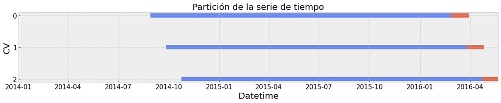

```python
plot_cv_indices(cv, sample, dt_col)
```

**Ejecutamos el modelo**

```python
#Obtenemos la identificacion de la tienda

%%time
stores = list(d_store_id.keys())
models = []
for store in stores:

    df = data[data['store_id']==store]
    df = df.reset_index(drop=True)
    df.drop('date', axis=1, inplace=True)
    X, y = df[df['d']<1914].drop('sold',axis=1), df[df['d']<1914]['sold']

    #Partimos los datos teniendo en cuenta la relacion temporal
    for idx_fold, (idx_trn, idx_val) in enumerate(cv.split(X, y)):

      print(f"\n----- Fold: ({idx_fold + 1} / {cv.get_n_splits()}) -----\n")
      X_train, X_valid = X.iloc[idx_trn], X.iloc[idx_val]
      y_train, y_valid = y.iloc[idx_trn], y.iloc[idx_val]



      #Primer modelo..... LGBOOST Regressor

      model = LGBMRegressor(
          n_estimators=1000,
          learning_rate=0.3,
          subsample=0.8,
          colsample_bytree=0.8,
          max_depth=8,
          num_leaves=50,
          min_child_weight=300
      )
      print('*****Predicciones para la tienda: {}*****'.format(d_store_id[store]))
      model.fit(X_train, y_train, eval_set=[(X_train,y_train),(X_valid,y_valid)],
              eval_metric='rmse', verbose=20, early_stopping_rounds=20)
      #valid_preds[X_valid.index] = model.predict(X_valid)

      models.append(model)

      filename = ruta+'modelo_LGB/'+'model'+str(d_store_id[store])+'.pkl'
      # save model
      joblib.dump(model, filename)
      del model, X_train, y_train, X_valid, y_valid, idx_trn, idx_val
```

```
----- Fold: (1 / 3) -----

*****Predicciones para la tienda: CA_1*****
Training until validation scores don't improve for 20 rounds.
[20]	training's l2: 0.237429	training's rmse: 0.487267	valid_1's l2: 0.24478	valid_1's rmse: 0.494752
[40]	training's l2: 0.193248	training's rmse: 0.4396	valid_1's l2: 0.227545	valid_1's rmse: 0.477016
[60]	training's l2: 0.174034	training's rmse: 0.417174	valid_1's l2: 0.216238	valid_1's rmse: 0.465014
[80]	training's l2: 0.156002	training's rmse: 0.394971	valid_1's l2: 0.20315	valid_1's rmse: 0.450722
[100]	training's l2: 0.143118	training's rmse: 0.37831	valid_1's l2: 0.192853	valid_1's rmse: 0.43915
[120]	training's l2: 0.136441	training's rmse: 0.369379	valid_1's l2: 0.190126	valid_1's rmse: 0.436035
[140]	training's l2: 0.130389	training's rmse: 0.361094	valid_1's l2: 0.189059	valid_1's rmse: 0.434809
[160]	training's l2: 0.121645	training's rmse: 0.348777	valid_1's l2: 0.180536	valid_1's rmse: 0.424896
[180]	training's l2: 0.115661	training's rmse: 0.34009	valid_1's l2: 0.177365	valid_1's rmse: 0.421147
[200]	training's l2: 0.11193	training's rmse: 0.33456	valid_1's l2: 0.176332	valid_1's rmse: 0.41992
[220]	training's l2: 0.108658	training's rmse: 0.329632	valid_1's l2: 0.174322	valid_1's rmse: 0.417519
[240]	training's l2: 0.104019	training's rmse: 0.32252	valid_1's l2: 0.169597	valid_1's rmse: 0.411821
[260]	training's l2: 0.0990011	training's rmse: 0.314644	valid_1's l2: 0.167784	valid_1's rmse: 0.409614
[280]	training's l2: 0.0957013	training's rmse: 0.309356	valid_1's l2: 0.167126	valid_1's rmse: 0.40881
[300]	training's l2: 0.0926527	training's rmse: 0.304389	valid_1's l2: 0.165348	valid_1's rmse: 0.406631
[320]	training's l2: 0.0903242	training's rmse: 0.30054	valid_1's l2: 0.162642	valid_1's rmse: 0.403289
[340]	training's l2: 0.0883704	training's rmse: 0.297272	valid_1's l2: 0.161679	valid_1's rmse: 0.402093
[360]	training's l2: 0.0868178	training's rmse: 0.294649	valid_1's l2: 0.160165	valid_1's rmse: 0.400206
[380]	training's l2: 0.0843703	training's rmse: 0.290466	valid_1's l2: 0.159172	valid_1's rmse: 0.398963
[400]	training's l2: 0.0829709	training's rmse: 0.288047	valid_1's l2: 0.160202	valid_1's rmse: 0.400252
Early stopping, best iteration is:
[382]	training's l2: 0.084147	training's rmse: 0.290081	valid_1's l2: 0.158849	valid_1's rmse: 0.398559

----- Fold: (2 / 3) -----

*****Predicciones para la tienda: CA_1*****
Training until validation scores don't improve for 20 rounds.
[20]	training's l2: 0.238168	training's rmse: 0.488024	valid_1's l2: 0.142209	valid_1's rmse: 0.377106
[40]	training's l2: 0.195344	training's rmse: 0.441978	valid_1's l2: 0.11947	valid_1's rmse: 0.345645
[60]	training's l2: 0.173816	training's rmse: 0.416912	valid_1's l2: 0.110511	valid_1's rmse: 0.332432
[80]	training's l2: 0.159478	training's rmse: 0.399347	valid_1's l2: 0.103466	valid_1's rmse: 0.321661
[100]	training's l2: 0.149537	training's rmse: 0.3867	valid_1's l2: 0.100154	valid_1's rmse: 0.316471
[120]	training's l2: 0.141382	training's rmse: 0.376007	valid_1's l2: 0.0997985	valid_1's rmse: 0.315909
[140]	training's l2: 0.135426	training's rmse: 0.368002	valid_1's l2: 0.0974366	valid_1's rmse: 0.312148
[160]	training's l2: 0.131051	training's rmse: 0.36201	valid_1's l2: 0.0971813	valid_1's rmse: 0.311739
[180]	training's l2: 0.124356	training's rmse: 0.352642	valid_1's l2: 0.0951285	valid_1's rmse: 0.308429
```

[output cut: 601 more lines]

```
[140]	training's l2: 0.119455	training's rmse: 0.345623	valid_1's l2: 0.162295	valid_1's rmse: 0.402859
[160]	training's l2: 0.113135	training's rmse: 0.336356	valid_1's l2: 0.154772	valid_1's rmse: 0.39341
[180]	training's l2: 0.107582	training's rmse: 0.327997	valid_1's l2: 0.150367	valid_1's rmse: 0.387772
[200]	training's l2: 0.102529	training's rmse: 0.320202	valid_1's l2: 0.148197	valid_1's rmse: 0.384963
[220]	training's l2: 0.0975604	training's rmse: 0.312347	valid_1's l2: 0.14484	valid_1's rmse: 0.380579
[240]	training's l2: 0.092478	training's rmse: 0.304102	valid_1's l2: 0.142539	valid_1's rmse: 0.377543
[260]	training's l2: 0.0905901	training's rmse: 0.300982	valid_1's l2: 0.142005	valid_1's rmse: 0.376836
[280]	training's l2: 0.0867097	training's rmse: 0.294465	valid_1's l2: 0.139904	valid_1's rmse: 0.374037
[300]	training's l2: 0.0843973	training's rmse: 0.290512	valid_1's l2: 0.139702	valid_1's rmse: 0.373767
[320]	training's l2: 0.081173	training's rmse: 0.284909	valid_1's l2: 0.138031	valid_1's rmse: 0.371525
[340]	training's l2: 0.0787078	training's rmse: 0.280549	valid_1's l2: 0.138111	valid_1's rmse: 0.371633
Early stopping, best iteration is:
[322]	training's l2: 0.0809719	training's rmse: 0.284556	valid_1's l2: 0.137232	valid_1's rmse: 0.370449
CPU times: user 3h 50min 48s, sys: 11.6 s, total: 3h 51min
Wall time: 7min 14s
```

**Evaluacion del modelo**

```python
##Tenemos 3 modelos por cada tienda. Vamos a realizar las predicciones y tenemos una mètrica realizando el promedio de cada uno.

models_CA1= models[0:3]
models_CA2 = models[3:6]
models_CA3 = models[6:9]
models_CA4 = models[9:12]
models_TX1 = models[12:15]
models_TX2 = models[15:18]
models_TX3 = models[18:21]
models_W1 = models[21:24]
models_W2 = models[24:27]
models_W3 = models[27:30]

models_ = {}
models_['CA_1'] = models_CA1
models_['CA_2'] = models_CA2
models_['CA_3'] = models_CA3
models_['CA_4'] = models_CA4
models_['TX_1'] = models_TX1
models_['TX_2'] = models_TX2
models_['TX_3'] = models_TX3
models_['WI_1'] = models_W1
models_['WI_2'] = models_W2
models_['WI_3'] = models_W3

df_stores = {}

for store,key in d_store_id.items():

    df_stores[key] =  X_test[X_test['store_id']==store]

###definicion del target para cada una de las tiendas
y_test_stores = {}

for store, df in df_stores.items():

  y_test_stores[store] = y_test.loc[df.index]
```

```python
def rmse(y_true, y_pred):
    return np.sqrt(mean_squared_error(y_true, y_pred))

preds = {}

for key, df in df_stores.items():

  preds[key] = np.zeros(df.shape[0])

for store, model in models_.items():

    for m in model:

      preds[store] += m.predict(df_stores[store])
      preds[store] / cv.get_n_splits()
```

```python
errors = {}

for store, predic in preds.items():

  errors[store] = rmse(y_test_stores[store].values, predic)
```

```python
errors
```

```
{'CA_1': 7.888680968245924,
 'CA_2': 7.120313735626317,
 'CA_3': 10.531286805484172,
 'CA_4': 4.357916523053722,
 'TX_1': 6.7379255198377725,
 'TX_2': 7.899581242540605,
 'TX_3': 7.810335691322196,
 'WI_1': 5.803090971240016,
 'WI_2': 10.737923024525845,
 'WI_3': 8.104978545944723}
```

**Funciones de desempeño**

```python
#Cargamos los modelos
models = {}
for filename in os.listdir(ruta + 'modelo_LGB/'):
    if 'model' in filename:
        #Cargando el modelo
        model = joblib.load(ruta + 'modelo_LGB/'+filename)
        models[filename] = model
```

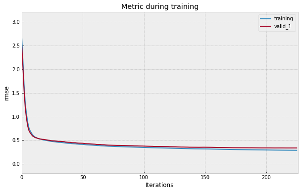

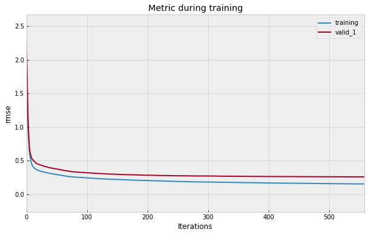

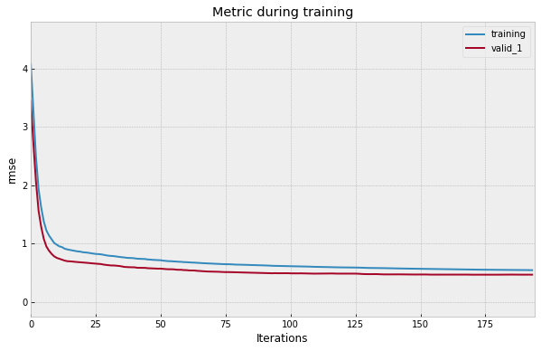

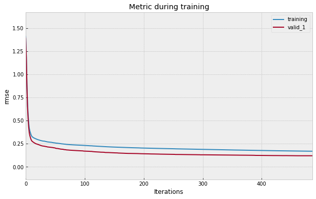

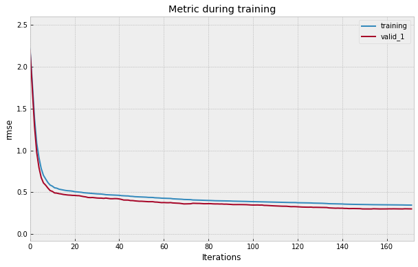

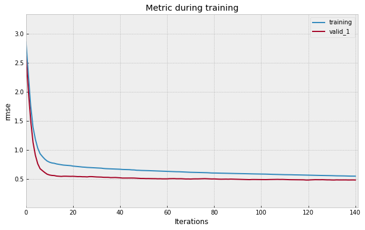

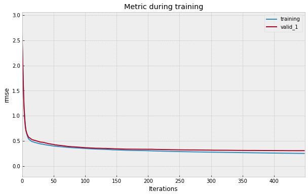

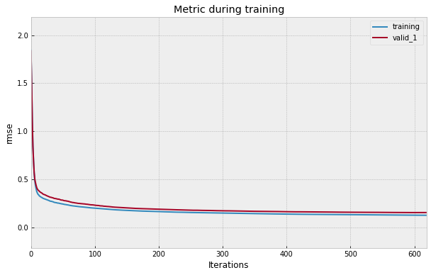

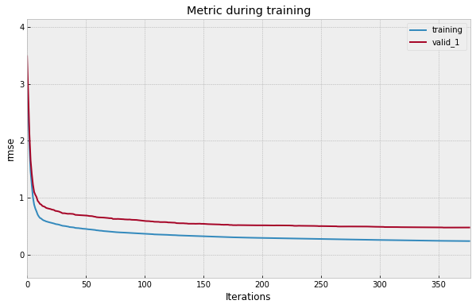

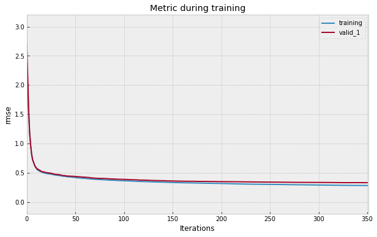

```python
for model in models.items():
  lgb.plot_metric(model[1], figsize=(10,6))
  plt.savefig(ruta+'modelo_LGB/perdida_'+model[0][:-4]+'.png', bbox_inches='tight')
```

```python
y_train = data[data['d']<1914]['sold']
y_test = valid['sold']
```

**Importancia de las variables**

```python
feature_importance_df = pd.DataFrame()
features = [f for f in data.columns if f != 'sold']
for filename in os.listdir(ruta + 'modelo_LGB/'):
    if 'model' in filename:
        #Cargando el modelo
        model = joblib.load(ruta + 'modelo_LGB/'+filename)
        store_importance_df = pd.DataFrame()
        store_importance_df["feature"] = features
        store_importance_df["importance"] = model.feature_importances_
        store_importance_df["store"] = filename[5:9]
        feature_importance_df = pd.concat([feature_importance_df, store_importance_df], axis=0)

def display_importances(feature_importance_df_):
    cols = feature_importance_df_[["feature", "importance"]].groupby("feature").mean().sort_values(by="importance", ascending=False)[:20].index
    best_features = feature_importance_df_.loc[feature_importance_df_.feature.isin(cols)]
    plt.figure(figsize=(10, 15))
    fig = px.bar(best_features.sort_values(by="importance", ascending=True), x="importance", y="feature",  title='LightGBM Variables Importantes (Promedio entre todas las tiendas evaluadas)')

    fig.show()

display_importances(feature_importance_df)
plotly.offline.plot(fig, filename = ruta+'/modelo_LGB/importancia_variables_LGB.html', auto_open=False)
```

[interactive chart not shown]

```
'/content/drive/MyDrive/Proyecto_topicos//modelo_LGB/importancia_variables_LGB.html'
```